# Time series theory (1/2)

## 3.2 Random walk

The simplest case is the **white noise**:
$$x_t= e_t,$$

but this is not very interesting.

**NoteDefinition**

A second important case is linked to the notion of **random walk**:
$$x_t=x_{t-1}+e_t, \tag{1}$$
and, **iterating**, we see that we have $x_t=\sum_{s=0}^t e_s$ - where we assume a starting point at $t=0$.

Notably, we have
$$\mathbb{E}[x_t]=\mathbb{E}\left[\sum_{s=1}^t e_s\right]=\sum_{s=1}^t\mathbb{E}\left[ e_s\right]=0.$$

Moreover, if the innovations are independent,

$$\mathbb{V}[x_t]=\mathbb{V}\left[\sum_{s=1}^t e_s\right]=\sum_{s=1}^t\mathbb{V}\left[ e_s\right]=t\sigma^2.$$

Hence, the variance increases with time - linearly. If perturbations are *not* independent, then it’s a bit more complicated and the variance will depend on all *auto-covariances*.

The covariance between two points in time is given by (number of overlapping times):

$$\mathbb{C}ov[x_t,x_{t+h}] = \mathbb{E}\left[\sum_{s=1}^t\sum_{r=1}^{t+h} e_se_r\right]=t\sigma^2, \quad h \ge 0.$$
This is because all innovation terms are independent, hence the only ones that are non-null are the $t$ terms of the form $\mathbb{C}ov[x_s,x_s]=\sigma^2$.

Hence, we see that both the variance and auto-covariance depend on $t$, say, the present time. This makes analysis complicated, because, depending on the moment we consider, the distribution of $x_t$ will change.

Nevertheless, note that
$$\mathbb{C}ov[x_t,x_{t-h}]=(t-h)\sigma^2.$$
So the general formula is
$$\mathbb{C}ov[x_t,x_{s}]=\sigma^2\min(s,t)$$

Let’s simulate one trajectory (on the right).

**R**

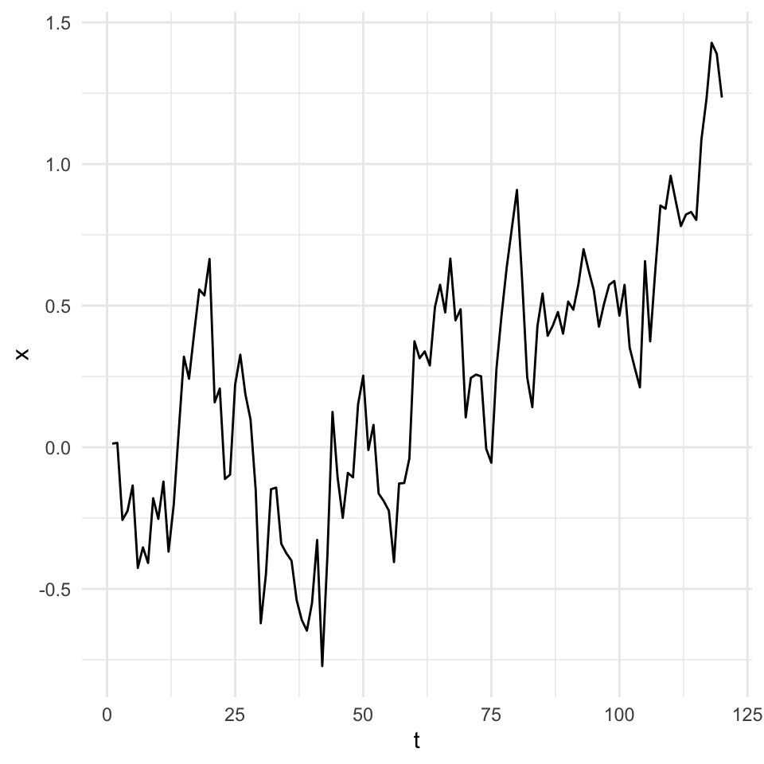

```r
#set.seed(42) # This freezes the random number generator
x <- cumsum(rnorm(N, mean = 0, sd = sigma))
tibble(t = 1:N, x = x) |>
  ggplot(aes(x = t, y = x)) + geom_line() + theme_minimal()
```

**Python**

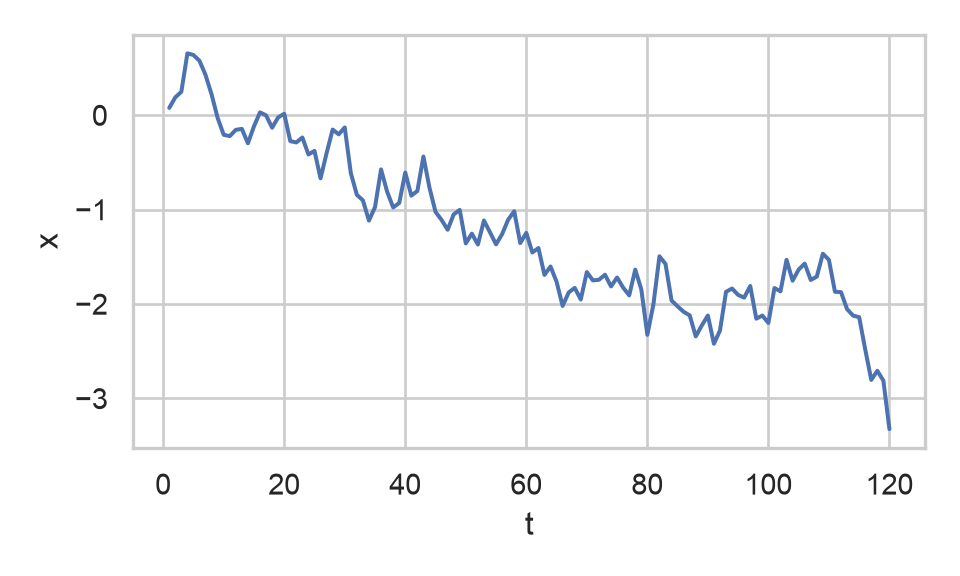

```python
x = np.cumsum(rng.normal(loc=0, scale=sigma, size=N))
fig, ax = plt.subplots(figsize=(5, 3))
ax.plot(np.arange(1, N + 1), x)
ax.set(xlabel="t", ylabel="x")
fig.tight_layout()
plt.show()
```

Ok but this is just **ONE** trajectory. There are an infinite number of possible paths!

**R**

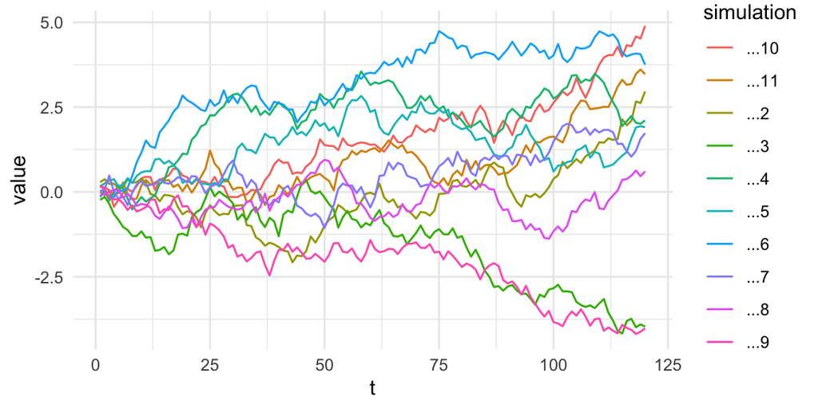

```r
#set.seed(42) # This freezes the random number generator
nb_traj <- 10
x <- matrix(rnorm(N*nb_traj, mean = 0, sd = sigma), ncol = nb_traj) |> apply(2, cumsum)
bind_cols(t = 1:N, x) |>
  pivot_longer(-t, names_to = "simulation", values_to = "value") |>
  ggplot(aes(x = t, y = value, color = simulation)) + geom_line() + theme_minimal()
```

**Python**

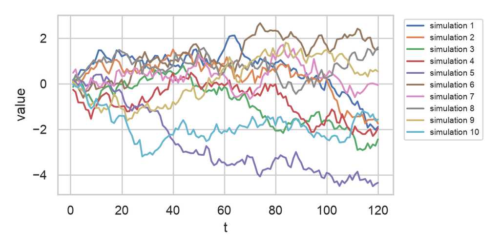

```python
nb_traj = 10
# Each column contains one trajectory, as in the R matrix.
x = np.cumsum(rng.normal(loc=0, scale=sigma, size=(N, nb_traj)), axis=0)
fig, ax = plt.subplots(figsize=(6, 3))
for j in range(nb_traj):
    ax.plot(np.arange(1, N + 1), x[:, j], label=f"simulation {j + 1}")
ax.set(xlabel="t", ylabel="value")
ax.legend(bbox_to_anchor=(1.02, 1), loc="upper left", fontsize=7)
fig.tight_layout()
plt.show()
```

## 3.3 Forecasting a random walk

For Gaussian IID innovations, known $\sigma$, and no drift, the best forecast is the **latest observation**.
$$\widehat X_{T+h\mid T}=X_T.$$
Here, the notation $|T$ means “*knowing the information at time* $T$”.
The 95% prediction interval is $X_T\pm1.96\sigma\sqrt h$; uncertainty grows with the horizon.

**R**

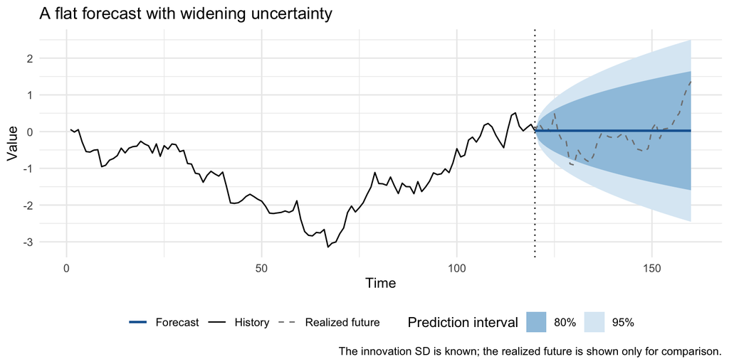

```r
withr::with_seed(201, {
  fc_T <- 120
  fc_H <- 40
  fc_sigma <- 0.2
  fc_path <- cumsum(rnorm(fc_T + fc_H, sd = fc_sigma))
  fc_h <- 0:fc_H
  fc_sd <- fc_sigma * sqrt(fc_h)
  fc_bands <- tibble(t = fc_T + fc_h, center = fc_path[fc_T],
    lo95 = fc_path[fc_T] - qnorm(0.975) * fc_sd,
    hi95 = fc_path[fc_T] + qnorm(0.975) * fc_sd,
    lo80 = fc_path[fc_T] - qnorm(0.9) * fc_sd,
    hi80 = fc_path[fc_T] + qnorm(0.9) * fc_sd)
  fc_history <- tibble(t = seq_len(fc_T), value = fc_path[seq_len(fc_T)])
  fc_future <- tibble(t = fc_T:(fc_T + fc_H),
                       value = fc_path[fc_T:(fc_T + fc_H)])
  print(ggplot() +
    geom_ribbon(data = fc_bands, aes(t, ymin = lo95, ymax = hi95, fill = "95%")) +
    geom_ribbon(data = fc_bands, aes(t, ymin = lo80, ymax = hi80, fill = "80%")) +
    geom_line(data = fc_history, aes(t, value, color = "History")) +
    geom_line(data = fc_future, aes(t, value, color = "Realized future"), linetype = 2) +
    geom_line(data = fc_bands, aes(t, center, color = "Forecast"), linewidth = 0.9) +
    geom_vline(xintercept = fc_T, linetype = 3) +
    scale_fill_manual(values = c("95%" = "#DCEAF5", "80%" = "#9EC5E0")) +
    scale_color_manual(values = c("History" = "black", "Realized future" = "gray50",
                                 "Forecast" = "#1764A0")) +
    labs(x = "Time", y = "Value", color = NULL, fill = "Prediction interval",
         title = "A flat forecast with widening uncertainty",
         caption = "The innovation SD is known; the realized future is shown only for comparison.") +
    theme_minimal() + theme(legend.position = "bottom"))
})
```

**Python**

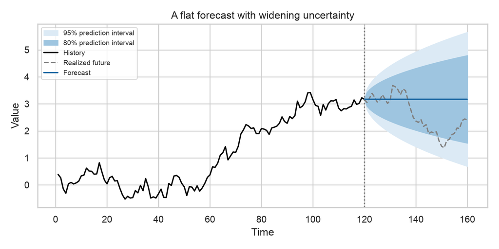

```python
fc_rng = np.random.default_rng(201)
fc_T, fc_H, fc_sigma = 120, 40, 0.2
fc_path = np.cumsum(fc_rng.normal(scale=fc_sigma, size=fc_T + fc_H))
fc_h = np.arange(fc_H + 1)
fc_times = fc_T + fc_h
fc_center = fc_path[fc_T - 1]
fc_sd = fc_sigma * np.sqrt(fc_h)
fig, ax = plt.subplots(figsize=(8, 4))
for level, z, color in [(95, stats.norm.ppf(0.975), "#DCEAF5"),
                         (80, stats.norm.ppf(0.9), "#9EC5E0")]:
    ax.fill_between(fc_times, fc_center - z * fc_sd, fc_center + z * fc_sd,
                    color=color, label=f"{level}% prediction interval")
ax.plot(np.arange(1, fc_T + 1), fc_path[:fc_T], color="black", label="History")
ax.plot(fc_times, fc_path[fc_T - 1:], color="gray", linestyle="--", label="Realized future")
ax.plot(fc_times, np.repeat(fc_center, fc_H + 1), color="#1764A0", label="Forecast")
ax.axvline(fc_T, color="gray", linestyle=":")
ax.set(xlabel="Time", ylabel="Value", title="A flat forecast with widening uncertainty")
ax.legend(fontsize=8, loc="best")
fig.tight_layout()
plt.show()
```

## 3.4 Deterministic versus stochastic trends

Let’s see what happens if we compare
$$Y_t=0.1t+\varepsilon_t$$
with
$$X_t=X_{t-1}+0.1+\varepsilon_t,$$
where $X_0=0$ and $\varepsilon_t$ is a Gaussian IID noise. If we simulate the paths and then:
1. subtract the deterministic trend from $Y_t$;
2. “differentiate” $X_t$ $\rightarrow$ we get the same result.

$\rightarrow$ An extra innovation of 5 at $t=100$ affects $Y_t$ temporarily (no memory), but it shifts $X_t$ permanently.

**R**

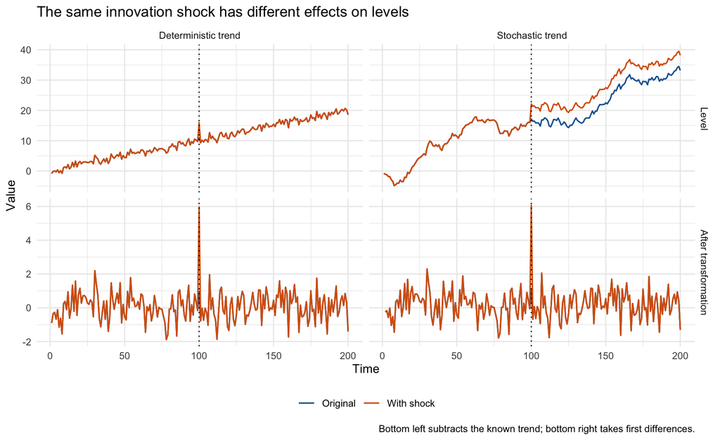

```r
withr::with_seed(202, {
  trend_n <- 200
  trend_t <- seq_len(trend_n)
  trend_e <- rnorm(trend_n, sd = 0.8)
  trend_y <- 0.1 * trend_t + trend_e
  trend_x <- 0.1 * trend_t + cumsum(trend_e)
  trend_y_shock <- trend_y + 5 * (trend_t == 100)
  trend_x_shock <- trend_x + 5 * (trend_t >= 100)
  trend_data <- bind_rows(
    tibble(t = trend_t, model = "Deterministic trend", stage = "Level",
           Original = trend_y, `With shock` = trend_y_shock),
    tibble(t = trend_t, model = "Stochastic trend", stage = "Level",
           Original = trend_x, `With shock` = trend_x_shock),
    tibble(t = trend_t, model = "Deterministic trend", stage = "After transformation",
           Original = trend_y - 0.1 * trend_t,
           `With shock` = trend_y_shock - 0.1 * trend_t),
    tibble(t = trend_t, model = "Stochastic trend", stage = "After transformation",
           Original = c(NA, diff(trend_x)), `With shock` = c(NA, diff(trend_x_shock)))
  ) |>
    mutate(stage = factor(stage, levels = c("Level", "After transformation"))) |>
    pivot_longer(c(Original, `With shock`), names_to = "scenario", values_to = "value")
  print(ggplot(trend_data, aes(t, value, color = scenario)) +
    geom_line(linewidth = 0.6, na.rm = TRUE) +
    geom_vline(xintercept = 100, linetype = 3) +
    facet_grid(stage ~ model, scales = "free_y") +
    scale_color_manual(values = c("Original" = "#1764A0", "With shock" = "#D95F02")) +
    labs(x = "Time", y = "Value", color = NULL,
         title = "The same innovation shock has different effects on levels",
         caption = "Bottom left subtracts the known trend; bottom right takes first differences.") +
    theme_minimal() + theme(legend.position = "bottom"))
})
```

**Python**

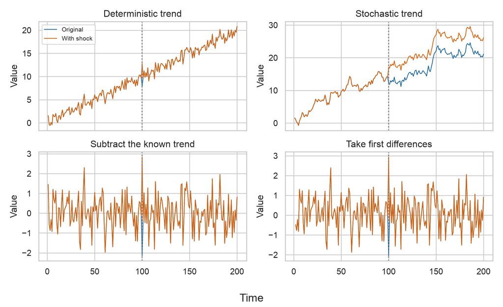

```python
trend_rng = np.random.default_rng(202)
trend_t = np.arange(1, 201)
trend_e = trend_rng.normal(scale=0.8, size=len(trend_t))
trend_y = 0.1 * trend_t + trend_e
trend_x = 0.1 * trend_t + np.cumsum(trend_e)
trend_y_shock = trend_y + 5 * (trend_t == 100)
trend_x_shock = trend_x + 5 * (trend_t >= 100)
fig, axes = plt.subplots(2, 2, figsize=(9, 5.5), sharex=True)
trend_panels = [
    (trend_y, trend_y_shock, "Deterministic trend"),
    (trend_x, trend_x_shock, "Stochastic trend"),
    (trend_y - 0.1 * trend_t, trend_y_shock - 0.1 * trend_t, "Subtract the known trend"),
    (np.r_[np.nan, np.diff(trend_x)], np.r_[np.nan, np.diff(trend_x_shock)], "Take first differences"),
]
for ax, (original, shocked, title) in zip(axes.flat, trend_panels):
    ax.plot(trend_t, original, color="#1764A0", label="Original", linewidth=0.9)
    ax.plot(trend_t, shocked, color="#D95F02", label="With shock", linewidth=0.9)
    ax.axvline(100, color="gray", linestyle=":")
    ax.set(title=title, ylabel="Value")
axes[0, 0].legend(fontsize=8)
fig.supxlabel("Time")
fig.tight_layout()
plt.show()
```

## 3.5 Spurious regression

### 3.5.1 Two independent random walks

We generate $T=200$ observations from

$$\begin{aligned}
X_t &= X_{t-1}+\varepsilon_t, & X_0&=0,\\
Y_t &= Y_{t-1}+\eta_t, & Y_0&=0,
\end{aligned}
\qquad
\varepsilon_t\sim\mathcal N(0,1),
\quad\eta_t\sim\mathcal N(0,1).
\tag{2}$$

All shocks are independent across both series and time, so $X$ and $Y$ have no relationship. Nevertheless, their movements can align by chance in a finite sample.

### 3.5.2 The misleading regression in levels

We fit a regression to the observed values, called the **levels**:

$$Y_t=\alpha+\beta X_t+u_t.
\tag{3}$$

The slope $\beta$ describes the relationship that the regression tries to find. Here, the true slope is zero. Random walks retain past shocks, and neighboring observations contain much of the same information. The usual regression test can mistake this persistence for evidence of a relationship. A small p-value, or a large $R^2$, can therefore be misleading.

### 3.5.3 The regression after differentiating

First differentiation implies to look at *changes* instead of *levels*:

$$\Delta X_t=X_t-X_{t-1}=\varepsilon_t,
\qquad
\Delta Y_t=Y_t-Y_{t-1}=\eta_t,
\qquad
\Delta Y_t=a+b\,\Delta X_t+v_t.
\tag{4}$$

The changes are just the independent shocks, so the true slope is again $b=0$. The usual regression test works correctly for these changes in this example.

**R**

```
# A tibble: 2 × 3
  transformation    R_squared  p_value
  <chr>                 <dbl>    <dbl>
1 Levels               0.0600 0.000472
2 First differences    0.0144 0.0914
```

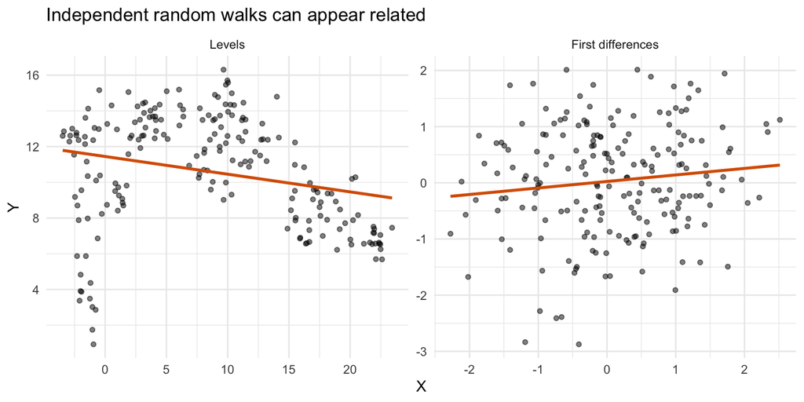

```r
withr::with_seed(203, {
  spur_x <- cumsum(rnorm(200))
  spur_y <- cumsum(rnorm(200))
  spur_data <- bind_rows(
    tibble(X = spur_x, Y = spur_y, transformation = "Levels"),
    tibble(X = diff(spur_x), Y = diff(spur_y), transformation = "First differences")) |>
    mutate(transformation = factor(transformation, levels = c("Levels", "First differences")))
  spur_fits <- list(Levels = lm(spur_y ~ spur_x),
                    `First differences` = lm(diff(spur_y) ~ diff(spur_x)))
  print(tibble(
    transformation = names(spur_fits),
    R_squared = sapply(spur_fits, function(fit) summary(fit)$r.squared),
    p_value = sapply(spur_fits, function(fit) coef(summary(fit))[2, 4])))
  print(ggplot(spur_data, aes(X, Y)) +
    geom_point(alpha = 0.5, size = 1.3) +
    geom_smooth(method = "lm", se = FALSE, color = "#D95F02") +
    facet_wrap(~ transformation, scales = "free", nrow = 1) +
    labs(title = "Independent random walks can appear related") + theme_minimal())
})
```

**Python**

```python
spur_rng = np.random.default_rng(203)
spur_x = np.cumsum(spur_rng.normal(size=200))
spur_y = np.cumsum(spur_rng.normal(size=200))
spur_pairs = [(spur_x, spur_y, "Levels"),
              (np.diff(spur_x), np.diff(spur_y), "First differences")]
spur_results = []
fig, axes = plt.subplots(1, 2, figsize=(8, 4))
for ax, (a, b, title) in zip(axes, spur_pairs):
    fit = stats.linregress(a, b)
    spur_results.append({"transformation": title, "R_squared": fit.rvalue ** 2,
                         "p_value": fit.pvalue})
    grid = np.linspace(a.min(), a.max(), 100)
    ax.scatter(a, b, alpha=0.5, s=12)
    ax.plot(grid, fit.intercept + fit.slope * grid, color="#D95F02")
    ax.set(title=title, xlabel="X", ylabel="Y")
print(pd.DataFrame(spur_results).to_string(index=False))
```

```
   transformation  R_squared  p_value
           Levels   0.065463 0.000255
First differences   0.002950 0.446125
```

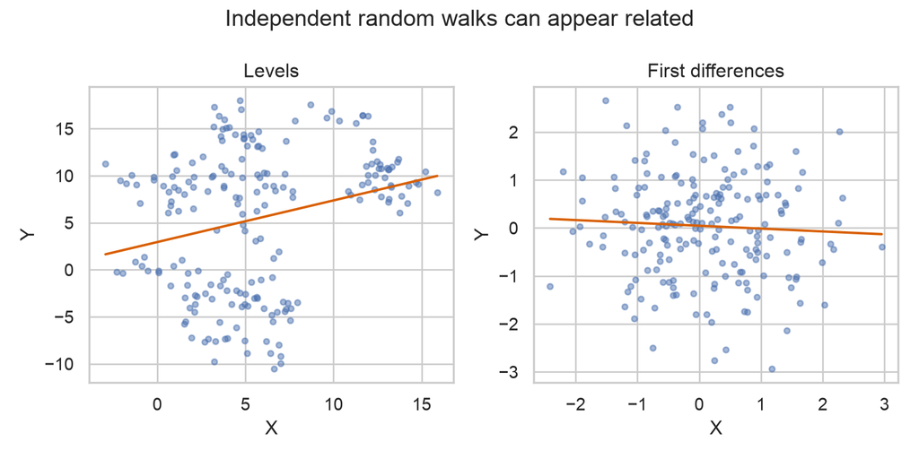

```python
fig.suptitle("Independent random walks can appear related")
fig.tight_layout()
plt.show()
```

### 3.5.4 How often does the test report a relationship?

If we repeat the experiment with 1,000 independent pairs and count how often the p-value falls below 0.05 we get the following results.  
Because the series are independent, each reported relationship is a **false positive**. A test working correctly should report about 5%, with some simulation variation. The plots below compare results for levels and changes (quite different!).

**R**

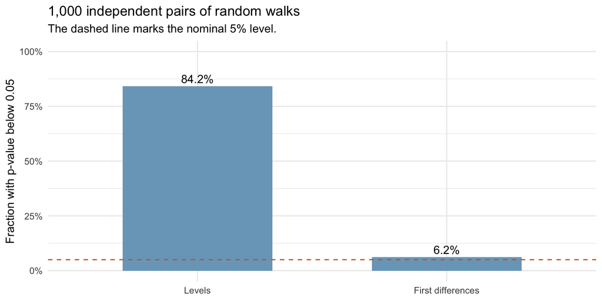

```r
withr::with_seed(204, {
  spur_p <- replicate(1000, {
    a <- cumsum(rnorm(200))
    b <- cumsum(rnorm(200))
    c(Levels = cor.test(a, b)$p.value,
      Differences = cor.test(diff(a), diff(b))$p.value)
  })
  spur_rates <- tibble(transformation = factor(c("Levels", "First differences"),
                        levels = c("Levels", "First differences")),
                       rate = rowMeans(spur_p < 0.05))
  print(ggplot(spur_rates, aes(transformation, rate)) +
    geom_col(fill = "#7AA6C2", width = 0.6) +
    geom_hline(yintercept = 0.05, color = "#D95F02", linetype = 2) +
    geom_text(aes(label = scales::percent(rate, accuracy = 0.1)), vjust = -0.4) +
    scale_y_continuous(limits = c(0, 1), labels = scales::label_percent()) +
    labs(x = NULL, y = "Fraction with p-value below 0.05",
         title = "1,000 independent pairs of random walks",
         subtitle = "The dashed line marks the nominal 5% level.") + theme_minimal())
})
```

**Python**

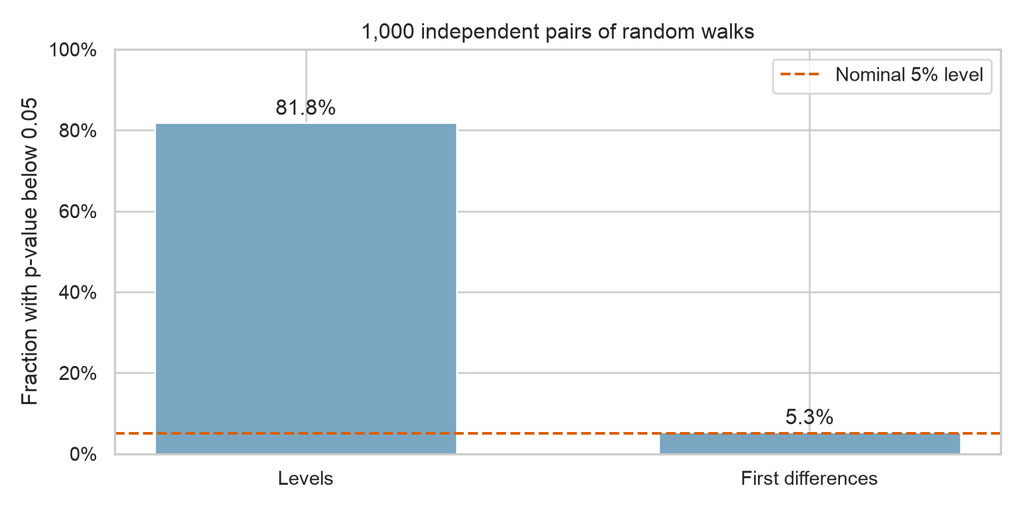

```python
spur_mc_rng = np.random.default_rng(204)
spur_p = np.empty((1000, 2))
for repetition in range(1000):
    a = np.cumsum(spur_mc_rng.normal(size=200))
    b = np.cumsum(spur_mc_rng.normal(size=200))
    spur_p[repetition] = [stats.linregress(a, b).pvalue,
                          stats.linregress(np.diff(a), np.diff(b)).pvalue]
spur_rates = (spur_p < 0.05).mean(axis=0)
fig, ax = plt.subplots(figsize=(8, 4))
ax.bar(["Levels", "First differences"], spur_rates, color="#7AA6C2", width=0.6)
ax.axhline(0.05, color="#D95F02", linestyle="--", label="Nominal 5% level")
for j, rate in enumerate(spur_rates):
    ax.text(j, rate + 0.02, f"{rate:.1%}", ha="center")
ax.set(ylim=(0, 1), ylabel="Fraction with p-value below 0.05",
       title="1,000 independent pairs of random walks")
ax.set_yticks(np.linspace(0, 1, 6), labels=[f"{p:.0%}" for p in np.linspace(0, 1, 6)])
ax.legend()
fig.tight_layout()
plt.show()
```

## 3.6 Unit root tests

Ok, but **how** can we determine that the process we are observing is a random walk?
Recall that from Equation 1, $x_t = x_{t-1}+e_t$. This is equivalent to
$$x_t = \rho x_{t-1}+e_t, \tag{5}$$
but for $\rho=1$. Hence we can estimate Equation 5 and test if $\rho=1$ or $\rho \neq 1$. Alternatively, it is more usual to test if $\delta=0$ in
$$\Delta x_t=x_t-x_{t-1}=\delta x_{t-1}+ e_t.$$

This is referred to as the [**Dickey-Fuller**](https://en.wikipedia.org/wiki/Dickey–Fuller_test) test. If $\delta=0$ (or $\rho=1$), then we say that there is a **unit root**.
The test can be generalized to more complex processes, for instance correcting for constant and trends (and seasonality $s_t$ potentially, too!):
$$\Delta x_t=a_0+a_1t +s_t+\delta x_{t-1}+e_t.$$

**NoteNOTE**

$\Delta x_t$ is called the **difference process**.

The **augmented Dickey-Fuller** test also includes more lags of the difference process in the regression:

$$\Delta x_t=a_0+a_1t+\delta_0x_{t-1}+\sum_{j=1}^J\delta_j \Delta x_{t-j}+e_t.$$

One example below.

The Python helper matches `tseries::adf.test` by including a constant, a linear trend, and the same fixed lag order. The libraries use different p-value approximations, so p-values can differ even for identical data. See the [statsmodels ADF documentation](https://www.statsmodels.org/stable/generated/statsmodels.tsa.stattools.adfuller.html).

**R**

```r
adf.test(x[,1])
```

```
    Augmented Dickey-Fuller Test

data:  x[, 1]
Dickey-Fuller = -1.0213, Lag order = 4, p-value = 0.9314
alternative hypothesis: stationary
```

**Python**

```python
def adf_test(series):
    values = np.asarray(pd.Series(np.asarray(series).ravel()).dropna(), dtype=float)
    lag_order = int(np.floor((len(values) - 1) ** (1 / 3)))
    # Match tseries::adf.test: an intercept, a trend, and fixed lag order.
    result = adfuller(values, maxlag=lag_order, regression="ct", autolag=None)
    return pd.Series({"ADF statistic": result[0], "p-value": result[1],
                      "Lag order": result[2], "Observations used": result[3]})

print(adf_test(x[:, 0]))
```

```
ADF statistic         -1.051046
p-value                0.936841
Lag order              4.000000
Observations used    115.000000
dtype: float64
```

```python
print("Null hypothesis: the series has a unit root.")
```

```
Null hypothesis: the series has a unit root.
```

How can we interpret this?

Use the displayed p-value to decide whether the null can be rejected at a user-specified **significance level**. The interpretation below follows the original R illustration; Python’s independent simulations can yield different conclusions.

**NoteLimitations of the DF test**

One of the main issues with the test is that the **null** (what we test, i.e., $\rho=1$ ) is synonymous with “**not stationary**”. (see just below for more on that…)  
This means that when H0 is rejected it means that the series is **not** *not stationary*.  
But this does not imply that it **is** *stationary*.

In fact a likely better test (that incorporates the variance) is the [**KPSS**](https://en.wikipedia.org/wiki/KPSS_test) test.  
In this test, the null is “*The series is stationary*”.  
KPSS p-values outside the tabulated range are reported at its bounds, usually 0.01 and 0.10. The test is more technical than the DF test; it looks at the sum of partial sums of residuals and is focused on variance (which is perhaps why it will work better on our examples below).

**R**

```r
kpss.test(x[,1])
```

```
    KPSS Test for Level Stationarity

data:  x[, 1]
KPSS Level = 1.2202, Truncation lag parameter = 4, p-value = 0.01
```

**Python**

```python
def kpss_test(series):
    values = np.asarray(pd.Series(np.asarray(series).ravel()).dropna(), dtype=float)
    # Match tseries::kpss.test's level null and short bandwidth.
    lag_order = int(np.floor(4 * (len(values) / 100) ** 0.25))
    result = kpss(values, regression="c", nlags=lag_order)
    return pd.Series({"KPSS statistic": result[0], "p-value": result[1],
                      "Truncation lag parameter": result[2]})

print(kpss_test(x[:, 0]))
```

```
KPSS statistic              1.348496
p-value                     0.010000
Truncation lag parameter    4.000000
dtype: float64
```

```python
print("Null hypothesis: the series is stationary around a constant level.")
```

```
Null hypothesis: the series is stationary around a constant level.
```

So not a lot of support for H0.  
$\rightarrow$ in this case, both tests agree.

## 3.7 Ok so what?

Simply put, if the test concludes that there is a unit root, what does that mean?

- The latest observation provides a forecast for a random walk without drift.
- Forecast uncertainty grows with the horizon, as the example above illustrates.

If there is no unit root, then we need to dig deeper and consider alternative (more sophisticated) models.

## 3.8 A crucial concept: stationarity

There are several definitions of stationarity. The common denominator is the requirement of **stability through time**. The whole point of time-series is **forecasting**. Now, to be able to forecast, the analyst needs to have some guarantees that the model she learns or builds will have value in the future. For this to hold, the time-series must show some form of *invariance*. Indeed, if empirical properties change all the time, then it is impossible to infer durable patterns. A simple example is stock prices. Compare the values of the APPLE or NVIDIA share price in 2000 and in 2025.

**R**

```r
tickers <- c("AAPL", "NVDA", "WMT", "XOM")
# Tickers: Apple, Nvidia, Walmart, Exxon
# Others: , "F", "DIS", "GE", "CVX", "MSFT", "GS"
min_date <- "2000-01-01"                      # Starting date
max_date <- "2026-11-20"                      # Ending date
prices <- getSymbols(tickers, src = 'yahoo',  # The data comes from Yahoo Finance
                     from = min_date,         # Start date
                     to = max_date,           # End date
                     auto.assign = TRUE,
                     warnings = FALSE) %>%
  map(~Ad(get(.))) %>%                        # Retrieving the data
  purrr::reduce(merge) %>%                    # Merge in one dataframe
  `colnames<-`(tickers)                       # Set the column names
prices |> head(4)
```

```
                AAPL       NVDA      WMT      XOM
2000-01-03 0.8363667 0.08920649 14.12074 16.91617
2000-01-04 0.7658528 0.08682460 13.59237 16.59217
2000-01-05 0.7770594 0.08396617 13.31497 17.49671
2000-01-06 0.7098141 0.07848715 13.46027 18.40123
```

**Python**

```python
tickers = ["AAPL", "NVDA", "WMT", "XOM"]
min_date = "2000-01-01"
max_date = "2026-11-20"
stock_quotes = yf.download(tickers, start=min_date, end=max_date,
                           auto_adjust=False, progress=False)
prices = stock_quotes["Adj Close"].reindex(columns=tickers)
if prices.empty or prices.isna().all().any():
    raise ValueError("Yahoo Finance returned no prices for one or more stocks.")
print(prices.head(4))
```

```
Ticker          AAPL      NVDA        WMT        XOM
Date
2000-01-03  0.836367  0.089206  14.120733  16.916183
2000-01-04  0.765853  0.086825  13.592365  16.592148
2000-01-05  0.777059  0.083966  13.314966  17.496693
2000-01-06  0.709814  0.078487  13.460266  18.401239
```

Not exactly the same…

**R**

```r
prices |> tail(4)
```

```
               AAPL   NVDA    WMT    XOM
2026-11-10 348.2454 168.89 125.55 164.47
2026-11-11 355.3600 173.73 125.67 166.71
2026-11-12 354.8800 166.19 126.19 169.78
2026-11-13 356.2700 162.85 128.09 170.59
```

**Python**

```python
print(prices.tail(4))
```

```
Ticker            AAPL        NVDA         WMT         XOM
Date
2026-11-10  348.245392  168.889999  125.550003  164.470001
2026-11-11  355.359985  173.729996  125.669998  166.710007
2026-11-12  354.880005  166.190002  126.190002  169.779999
2026-11-13  356.269989  162.850006  128.089996  170.589996
```

Visually, this is easy to see: we cannot study asset prices in 2000-2010 and assume that the model will be relevant in 2026…

**R**

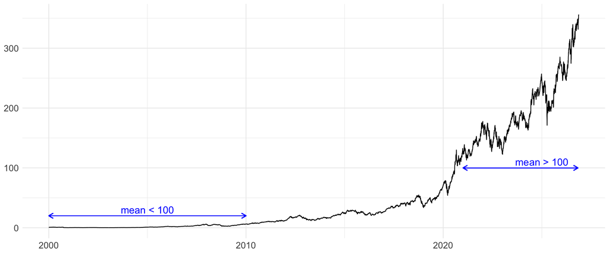

```r
prices |>
  data.frame() |>
  rownames_to_column(var = "date") |>
  ggplot(aes(x = as.Date(date), y = AAPL)) + geom_line() +
  geom_segment(x = as.Date("2000-01-01"), xend = as.Date("2010-01-01"), y = 20, yend = 20,
               arrow = arrow(ends = "both", length = unit(0.25, "cm")), color = "blue") +
  annotate("text", x = as.Date("2005-01-01"), y = 30, label = "mean < 100", color = "blue", size = 5) +
  geom_segment(x = as.Date("2021-01-01"), xend = as.Date("2026-11-01"), y = 100, yend = 100,
               arrow = arrow(ends = "both", length = unit(0.25, "cm")), color = "blue") +
  annotate("text", x = as.Date("2025-01-01"), y = 110, label = "mean > 100", color = "blue", size = 5) +
  theme_minimal() +
  theme(axis.title = element_blank(),
        text = element_text(size = 16))
```

**Python**

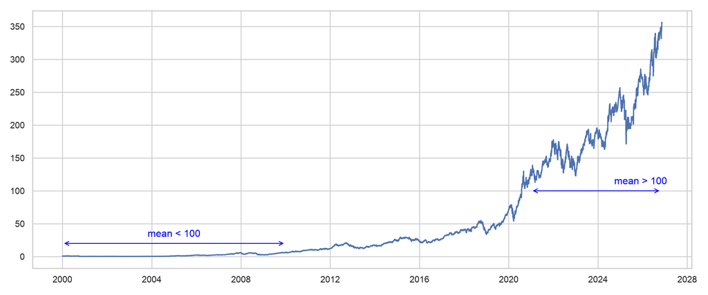

```python
fig, ax = plt.subplots(figsize=(12, 5))
ax.plot(prices.index, prices["AAPL"])
for start, end, height in [("2000-01-01", "2010-01-01", 20),
                            ("2021-01-01", "2026-11-01", 100)]:
    ax.annotate("", xy=(pd.Timestamp(end), height),
                xytext=(pd.Timestamp(start), height),
                arrowprops={"arrowstyle": "<->", "color": "blue"})
ax.text(pd.Timestamp("2005-01-01"), 30, "mean < 100", color="blue", ha="center")
ax.text(pd.Timestamp("2025-12-01"), 110, "mean > 100", color="blue", ha="center")
ax.set(xlabel="", ylabel="")
fig.tight_layout()
plt.show()
```

In finance, raw data is usually **not stationary**.  
But what’s a trick we have seen that can transform a non-stationary series into a stationary one? Inspired by unit root tests…  
$\rightarrow$ *Differentiation*!

The problem is that differentiation won’t work well because there is a scale issue. If $p_t \approx1$ or if $p_t \approx 1,000$, the variations won’t have the same magnitudes. We show this on the right.

**R**

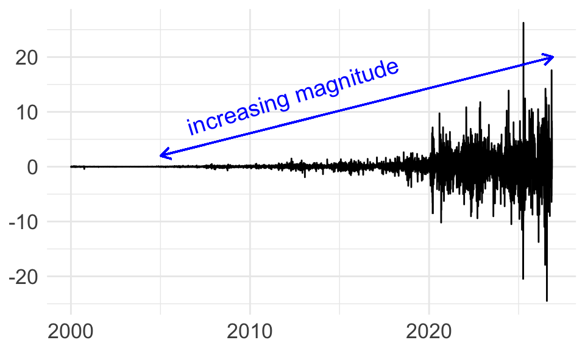

```r
prices |>
  data.frame() |>
  rownames_to_column(var = "date") |>
  ggplot(aes(x = as.Date(date), y = AAPL - lag(AAPL))) + geom_line() +
  geom_segment(x = as.Date("2005-01-01"), xend = as.Date("2026-12-01"), y = 2, yend = 20,
               arrow = arrow(ends = "both", length = unit(0.25, "cm")), color = "blue") +
  annotate("text", x = as.Date("2012-06-01"), y = 13, label = "increasing magnitude", color = "blue", size = 5, angle = 17) +
  theme_minimal() +
  theme(axis.title = element_blank(),
        text = element_text(size = 16))
```

**Python**

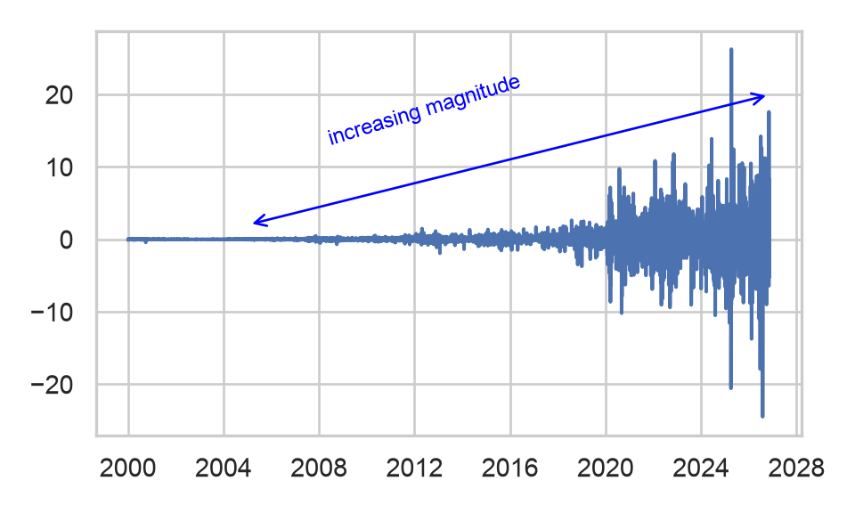

```python
fig, ax = plt.subplots(figsize=(5, 3))
ax.plot(prices.index, prices["AAPL"].diff())
ax.annotate("", xy=(pd.Timestamp("2026-12-01"), 20),
            xytext=(pd.Timestamp("2005-01-01"), 2),
            arrowprops={"arrowstyle": "<->", "color": "blue"})
ax.text(pd.Timestamp("2012-06-01"), 13, "increasing magnitude",
        color="blue", rotation=17, ha="center", fontsize=9)
ax.set(xlabel="", ylabel="")
fig.tight_layout()
plt.show()
```

Hence, we use **relative variations** (they are called *returns* in finance):

$$r_t = \frac{p_t-p_{t-1}}{p_{t-1}}.$$

And magnitudes remain *roughly* comparable throughout the sample.

**R**

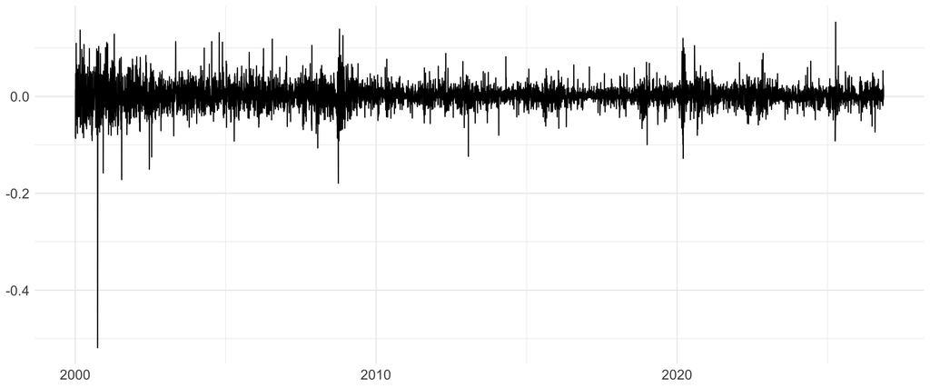

```r
prices |>
  data.frame() |>
  rownames_to_column(var = "date") |>
  ggplot(aes(x = as.Date(date), y = AAPL/lag(AAPL)-1)) + geom_line() +
  theme_minimal() +
  theme(axis.title = element_blank(),
        text = element_text(size = 16))
```

**Python**

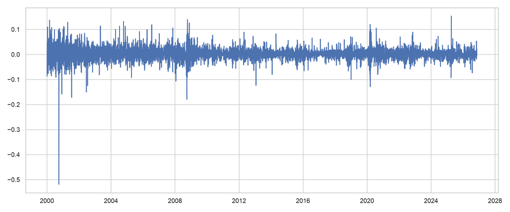

```python
fig, ax = plt.subplots(figsize=(12, 5))
ax.plot(prices.index, prices["AAPL"].pct_change(fill_method=None))
ax.set(xlabel="", ylabel="")
fig.tight_layout()
plt.show()
```

Now let’s turn to definitions of **stationarity**. The most strict formulation is the following.

**NoteStrict stationarity**

Mathematically, this means, in terms of **distribution functions**:
$$F_{X_{t_1}, X_{t_2}, \ldots, X_{t_n}}(x_1, x_2, \ldots, x_n) = F_{X_{t_1+h}, X_{t_2+h}, \ldots, X_{t_n+h}}(x_1, x_2, \ldots, x_n)$$
for all $n \in \mathbb{N}$, all $t_1, \ldots, t_n, h \in T$, and all $x_1, \ldots, x_n \in \mathbb{R}$.

This definition is a bit tough and **not very practical**. It’s hard to test and not necessarily useful.  
Focusing on the (much simpler) first two (co-)moments is easier and workable.

**NoteWeak stationarity**

- The mean function is constant: $\mathbb{E}[X_t] = \mu \quad \text{for all } t \in T$;
- The variance is finite: $\text{Var}(X_t) = \mathbb{E}[(X_t - \mu)^2] < \infty \quad \text{for all } t \in T$;  
  The autocovariance function depends only on the time lag: $\text{Cov}(X_t, X_{t+h}) = \gamma(h) \quad \text{for all } t, h \in T$,

where $\gamma(h) = \mathbb{E}[(X_t - \mu)(X_{t+h} - \mu)]$ is the autocovariance function at lag $h$.  
In particular, the **variance** is constant through time, too.

Assuming series are detrended (and de-seasonalized), the Dickey-Fuller test provides a way to determine if series are stationary or not.

# 4 Application to real data

## 4.1 Airline traffic

We recycle the code from the previous session.

**R**

```r
url <- "https://github.com/shokru/coqueret.github.io/raw/refs/heads/master/files/misc/time_series/traffic-sheet.xlsx"
airline <- read.xlsx(url, sheet = 3, startRow = 2)
air_data <- airline |> select(1:3)                  # Keep only the first 3 columns
colnames(air_data) <- c("date", "CDG", "ORY")       # Rename these columns
air_data <- air_data |>                             # Reformat the date
  mutate(date = as.Date(as.numeric(date), origin = "1899-12-30")) |>
  filter(is.finite(date), is.finite(CDG)) |>
  arrange(date) |>
  mutate(date = yearmonth(date)) |>
  distinct(date, .keep_all = T) |>
  as_tsibble() |>
  fill_gaps()
air_data |> head(4)
```

```
# A tsibble: 4 x 3 [1M]
      date     CDG     ORY
     <mth>   <dbl>   <dbl>
1 2000 Jan 3223328 1935261
2 2000 Feb 3289676 1942750
3 2000 Mar 3891206 2204640
4 2000 Apr 4221430 2266448
```

**Python**

```python
url = "https://github.com/shokru/coqueret.github.io/raw/refs/heads/master/files/misc/time_series/traffic-sheet.xlsx"
response = requests.get(url, timeout=120)
response.raise_for_status()
airline = pd.read_excel(io.BytesIO(response.content), sheet_name=2, header=1)
air_data = airline.iloc[:, :3].copy()
air_data.columns = ["date", "CDG", "ORY"]
# openpyxl usually converts Excel dates to datetime objects already.
if pd.api.types.is_numeric_dtype(air_data["date"]):
    air_data["date"] = pd.to_datetime(
        air_data["date"], unit="D", origin="1899-12-30", errors="coerce",
    )
else:
    air_data["date"] = pd.to_datetime(air_data["date"], errors="coerce")
for column in ["CDG", "ORY"]:
    air_data[column] = pd.to_numeric(air_data[column], errors="coerce")
air_data = air_data.loc[air_data["date"].notna() & np.isfinite(air_data["CDG"])]
air_data = air_data.sort_values("date")
air_data["date"] = air_data["date"].dt.to_period("M")
air_data = air_data.drop_duplicates("date").set_index("date")
air_data = air_data.reindex(pd.period_range(
    air_data.index.min(), air_data.index.max(), freq="M", name="date",
))
print(air_data.head(4))
```

```
               CDG        ORY
date
2000-01  3223328.0  1935261.0
2000-02  3289676.0  1942750.0
2000-03  3891206.0  2204640.0
2000-04  4221430.0  2266448.0
```

But we first need to remove the **seasonality** component. Both versions use STL with a fixed monthly seasonal pattern. The Python code explicitly matches R’s periodic smoother, smoothing spans, and iteration settings.

**R**

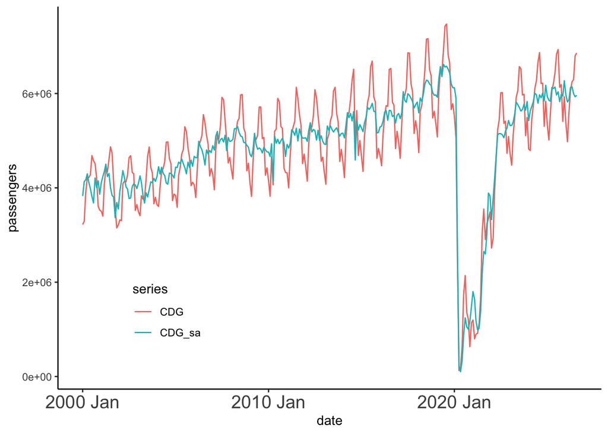

```r
cdg <- ts(air_data$CDG, frequency = 12)
decomp <- stl(cdg, s.window = "periodic")
CDG_sa <- seasadj(decomp)
bind_cols(air_data[,-3], CDG_sa = CDG_sa) |>
  pivot_longer(-date, names_to = "series", values_to = "passengers") |>
  ggplot(aes(x = date, y = passengers, color = series)) + geom_line() +
  theme_classic() +
  theme(legend.position = c(0.2,0.2), axis.text.x = element_text(size = 15))
```

**Python**

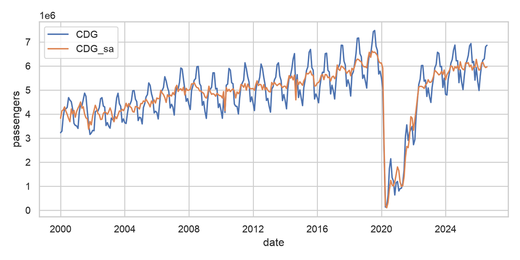

```python
cdg = air_data["CDG"].to_timestamp()
# Reproduce R's periodic STL smoother and default iteration settings.
seasonal_window = 10 * len(cdg) + 1
stl_result = STL(
    cdg, period=12, seasonal=seasonal_window, seasonal_deg=0,
    trend=19, low_pass=13, trend_deg=1, low_pass_deg=1,
    seasonal_jump=int(np.ceil(seasonal_window / 10)),
    trend_jump=2, low_pass_jump=2,
).fit(inner_iter=2, outer_iter=0)
# R's periodic option averages the fitted seasonal component by calendar month.
periodic_seasonal = stl_result.seasonal.groupby(cdg.index.month).transform("mean")
CDG_sa = cdg - periodic_seasonal
fig, ax = plt.subplots(figsize=(8, 4))
ax.plot(cdg.index, cdg, label="CDG")
ax.plot(CDG_sa.index, CDG_sa, label="CDG_sa")
ax.set(xlabel="date", ylabel="passengers")
ax.legend()
fig.tight_layout()
plt.show()
```

Ok so now we can move on and **test** for stationarity.  
**NOTE**: by default, the test adds a **constant** and a **linear trend**.

**R**

```r
adf.test(x = CDG_sa)
```

```
    Augmented Dickey-Fuller Test

data:  CDG_sa
Dickey-Fuller = -3.2488, Lag order = 6, p-value = 0.08002
alternative hypothesis: stationary
```

**Python**

```python
print(adf_test(CDG_sa))
```

```
ADF statistic         -3.248792
p-value                0.075110
Lag order              6.000000
Observations used    313.000000
dtype: float64
```

The result is not super clean cut…

- **H0**: not stationary
- **H1**: stationary

Small p-value: “evidence” against the null… (The probability, under the null H0, to observe data as extreme as the one we have, is weak.)

With KPSS:

**R**

```r
kpss.test(x = CDG_sa)
```

```
    KPSS Test for Level Stationarity

data:  CDG_sa
KPSS Level = 0.56736, Truncation lag parameter = 5, p-value = 0.02649
```

**Python**

```python
print(kpss_test(CDG_sa))
```

```
KPSS statistic              0.567364
p-value                     0.026495
Truncation lag parameter    5.000000
dtype: float64
```

So here the test rejects the null!

## 4.2 Carbon concentration

Same but with CO2 data. Both versions skip NOAA comment lines and recognize `-99.99` as a missing value. The test helpers omit missing observations.

**R**

```r
url <- "https://gml.noaa.gov/webdata/ccgg/trends/co2/co2_mm_mlo.csv"
co2 <- read.csv(url, comment.char = "#", na.strings = "-99.99")
co2 <- co2 |>
  mutate(date = make_date(year = year, month = month, day = 15)) |>
  select(date, average, deseasonalized) |>
  mutate(date_iso = date,
         date = yearmonth(date)) |>
  as_tsibble(index = date)
adf.test(x = na.omit(co2$deseasonalized))
```

```
    Augmented Dickey-Fuller Test

data:  na.omit(co2$deseasonalized)
Dickey-Fuller = -0.37184, Lag order = 9, p-value = 0.9876
alternative hypothesis: stationary
```

**Python**

```python
url = "https://gml.noaa.gov/webdata/ccgg/trends/co2/co2_mm_mlo.csv"
response = requests.get(url, timeout=120)
response.raise_for_status()
co2 = pd.read_csv(io.StringIO(response.text), comment="#", skipinitialspace=True,
                  na_values=[-99.99])
co2["date_iso"] = pd.to_datetime(co2[["year", "month"]].assign(day=15))
co2["date"] = co2["date_iso"].dt.to_period("M")
co2 = co2.set_index("date")[["average", "deseasonalized", "date_iso"]]
print(adf_test(co2["deseasonalized"]))
```

```
ADF statistic         -0.371838
p-value                0.987695
Lag order              9.000000
Observations used    813.000000
dtype: float64
```

Potential problem here: the “drift” may not be linear, but quadratic…

**R**

```r
kpss.test(x = na.omit(co2$deseasonalized))
```

```
    KPSS Test for Level Stationarity

data:  na.omit(co2$deseasonalized)
KPSS Level = 11.649, Truncation lag parameter = 6, p-value = 0.01
```

**Python**

```python
print(kpss_test(co2["deseasonalized"]))
```

```
KPSS statistic              11.648531
p-value                      0.010000
Truncation lag parameter     6.000000
dtype: float64
```

The test again rejects the null of stationarity.

## 4.3 Finance

So for the sake of obviousness, let’s run a DF test on NVDA prices… (The data was loaded above)

**R**

```r
nvda <- prices[,2]
adf.test(nvda)
```

```
    Augmented Dickey-Fuller Test

data:  nvda
Dickey-Fuller = -0.52365, Lag order = 18, p-value = 0.9808
alternative hypothesis: stationary
```

**Python**

```python
nvda = prices["NVDA"]
print(adf_test(nvda))
```

```
ADF statistic          -0.523653
p-value                 0.982477
Lag order              18.000000
Observations used    6739.000000
dtype: float64
```

That was to be expected. We cannot reject the null of *no stationarity*.

**R**

```r
kpss.test(nvda)
```

```
    KPSS Test for Level Stationarity

data:  nvda
KPSS Level = 22.341, Truncation lag parameter = 11, p-value = 0.01
```

**Python**

```python
print(kpss_test(nvda))
```

```
KPSS statistic              22.340988
p-value                      0.010000
Truncation lag parameter    11.000000
dtype: float64
```

No big surprise: the tests agree. Though in this case, we reject the null of *stationarity*.

Next, what about simple differences?

**R**

```r
adf.test(na.omit(nvda - stats::lag(nvda)))
```

```
    Augmented Dickey-Fuller Test

data:  na.omit(nvda - stats::lag(nvda))
Dickey-Fuller = -17.101, Lag order = 18, p-value = 0.01
alternative hypothesis: stationary
```

**Python**

```python
print(adf_test(nvda.diff().dropna()))
```

```
ADF statistic         -17.100883
p-value                 0.000000
Lag order              18.000000
Observations used    6738.000000
dtype: float64
```

So we must reject the null of no-stationarity. Here, the problem is that the DF test implies that there is **no unit root**.  
But this does not mean that the series are stationary either! That’s an important subtlelty.  
Let’s look at the KPSS outcome.

**R**

```r
kpss.test(na.omit(nvda - stats::lag(nvda)))
```

```
    KPSS Test for Level Stationarity

data:  na.omit(nvda - stats::lag(nvda))
KPSS Level = 0.4934, Truncation lag parameter = 11, p-value = 0.04315
```

**Python**

```python
print(kpss_test(nvda.diff().dropna()))
```

```
KPSS statistic               0.493401
p-value                      0.043153
Truncation lag parameter    11.000000
dtype: float64
```

Et voilà! Here the tests “disagree” with regard to stationarity. Though, again, DF does not really test for stationarity strictly speaking.  
But it is KPSS that is “correct”.

Now let’s turn to returns…

**R**

```r
adf.test(na.omit(nvda/stats::lag(nvda) - 1))
```

```
    Augmented Dickey-Fuller Test

data:  na.omit(nvda/stats::lag(nvda) - 1)
Dickey-Fuller = -17.954, Lag order = 18, p-value = 0.01
alternative hypothesis: stationary
```

**Python**

```python
print(adf_test(nvda.pct_change(fill_method=None).dropna()))
```

```
ADF statistic         -17.954416
p-value                 0.000000
Lag order              18.000000
Observations used    6738.000000
dtype: float64
```

**R**

```r
kpss.test(na.omit(nvda/stats::lag(nvda) - 1))
```

```
    KPSS Test for Level Stationarity

data:  na.omit(nvda/stats::lag(nvda) - 1)
KPSS Level = 0.11077, Truncation lag parameter = 11, p-value = 0.1
```

**Python**

```python
print(kpss_test(nvda.pct_change(fill_method=None).dropna()))
```

```
KPSS statistic               0.110769
p-value                      0.100000
Truncation lag parameter    11.000000
dtype: float64
```

Here the result for KPSS is not super clear cut, but it does seem that the two test point towards **stationarity**.  
**FINALLY** !!!!

The table below summarizes the original R illustration. Online data revisions and p-value approximations can change the empirical conclusions.

| test | prices | simple difference | returns |
| --- | --- | --- | --- |
| DF test | not stationary | stationary | stationary |
| KPSS test | not stationary | not stationary | stationary |

To close this session, let’s recall a typical representation of returns (quite abstract).  
Below, the returns of Apple.

**R**

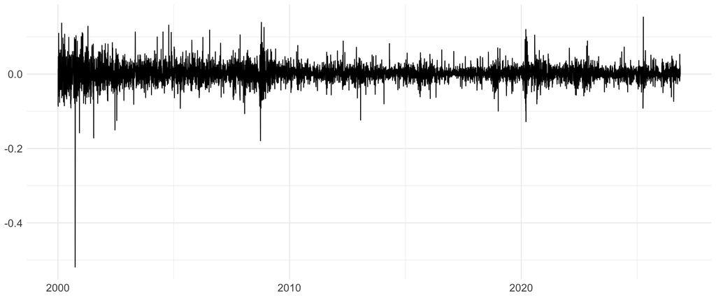

```r
prices |>
  data.frame() |>
  rownames_to_column(var = "date") |>
  ggplot(aes(x = as.Date(date), y = AAPL/lag(AAPL)-1)) + geom_line() +
  theme_minimal() +
  theme(axis.title = element_blank(),
        text = element_text(size = 16))
```

**Python**

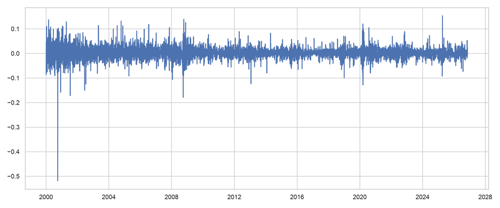

```python
fig, ax = plt.subplots(figsize=(12, 5))
ax.plot(prices.index, prices["AAPL"].pct_change(fill_method=None))
ax.set(xlabel="", ylabel="")
fig.tight_layout()
plt.show()
```

And below, a plot of simulations of white noise. Can you spot a difference?

**R**

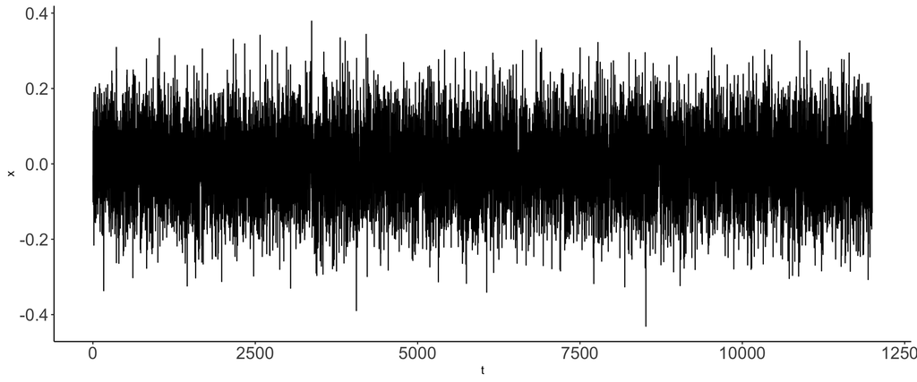

```r
data.frame(t = 1:(100*N), x = rnorm(100*N)/10) |>
  ggplot(aes(x = t, y = x)) + theme_classic() + geom_line() +
  theme(axis.text = element_text(size = 16))
```

**Python**

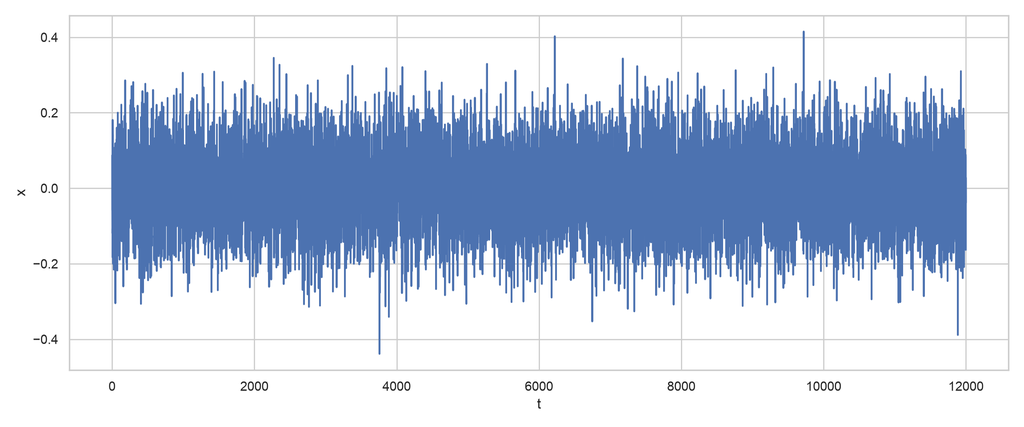

```python
noise = rng.normal(size=100 * N) / 10
fig, ax = plt.subplots(figsize=(12, 5))
ax.plot(np.arange(1, len(noise) + 1), noise)
ax.set(xlabel="t", ylabel="x")
fig.tight_layout()
plt.show()
```

## 4.4 Exercise: reproduce these tests on crypto data!

Use the cryptocurrency examples in the first notebook to obtain daily closing prices. Apply the ADF and KPSS tests to prices, first differences, and returns in either language. Compare the statistics and p-values before drawing conclusions about stationarity.